# mlr3_for_lab

2024-09-04

```r
# remotes::install_github("mlr-org/mlr3learners")
# remotes::install_github("mlr-org/mlr3extralearners")
# remotes::install_github("mlr-org/mlr3spatiotempcv")
# remotes::install_github("mlr-org/mlr3tuning")
# remotes::install_github("mlr-org/mlr3tuningspaces")
# remotes::install_github("mlr-org/mlr3proba")
# remotes::install_github("mlr-org/mlr3pipelines")
# remotes::install_github("mlr-org/mlr3mbo")
# remotes::install_github("mlr-org/mlr3fselect")


library(dplyr)
library(ggplot2)
library(sf)
library(mlr3)               # unified interface to machine learning algorithms
library(mlr3learners)       # most important machine learning algorithms
library(mlr3extralearners)  # access to even more learning algorithms
library(mlr3spatiotempcv)   # spatio-temporal resampling strategies
library(mlr3viz)           # plotting functions for mlr3 objects
library(mlr3tuning)         # hyperparameter tuning
library(mlr3tuningspaces)   # suggested hyperparameter tuning spaces
#library(mlr3pipelines)
#library(mlr3mbo)
#library(patchwork)
#library(terra)
#library(future)           # parallel processing
#library(progressr)        # report progress updates
#library(mlr3fselect)
library(paradox)
```

# R workflow

## 1. Basic model

I’m going to use the “ecuador” data from the mlr3spatiotemp library. This dataset contains landslide information from Ecuador, 2000.

```r
data(ecuador)
```

Just to get an idea of this data, I’ll explore the spatial distribution of feature values. It appears some variables display obvious spatial autocorrelation, including `dem`, `distdeforest`, and `distroad`.

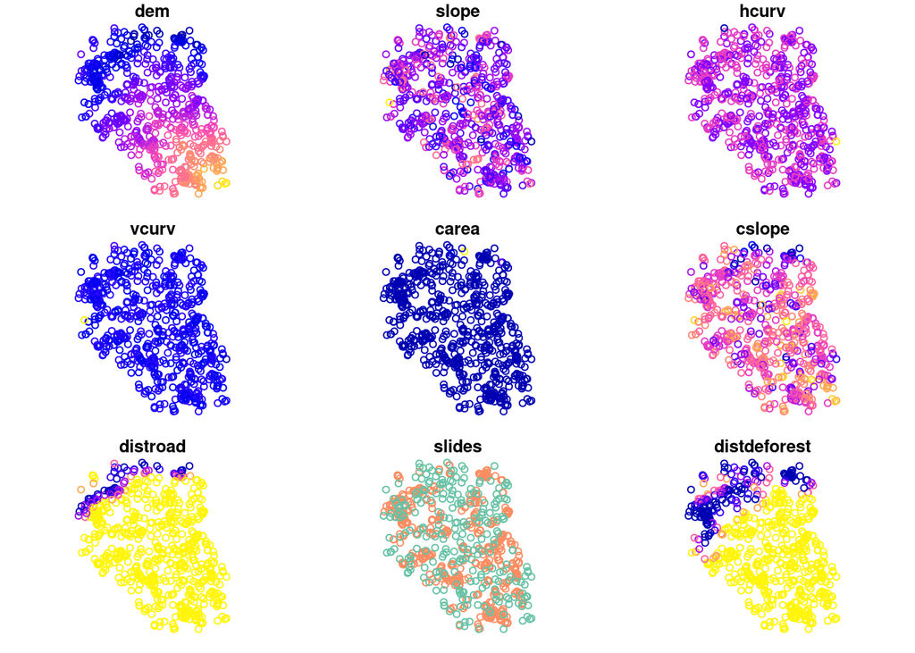

```r
ecuador %>%
  st_as_sf(coords = c("x", "y"), crs = 32717) %>%
  plot()
```

I’m going to set aside the eastern region of data for validation (this is a bit brute force!).

```r
# use lat ("x") to label 70% as data as training and 30% as validation
ecuador <- ecuador %>%
  arrange(x) %>%
  mutate(rowid = row_number()) %>%
  mutate(set = ifelse(rowid < 0.7*nrow(.), "training", "validation"))

# separate training and testing
train <- ecuador %>% filter(set == "training") %>% select(-c(set, rowid))
val <- ecuador %>% filter(set == "validation") %>% select(-c(set, rowid))
```

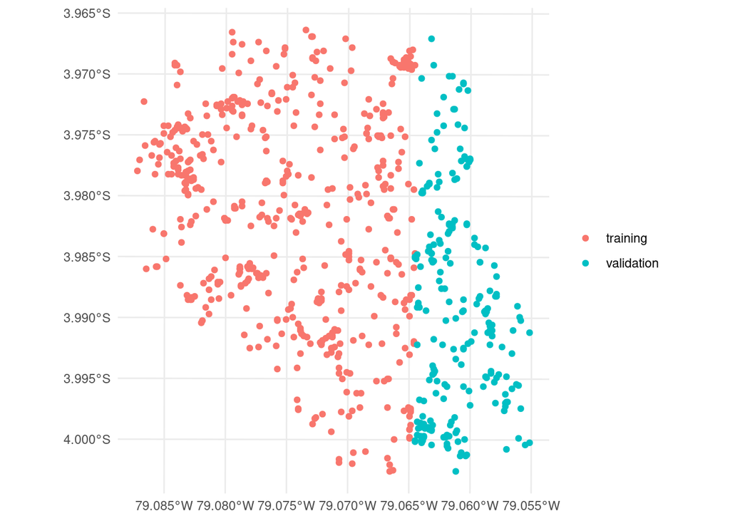

### 1.1 Tasks

I start by specifying our task. Here, my task is a spatial (“st”) classification (“classif”). The `target` is our response variable, which needs to be a factor variable type. `positive` is the target value for “true” in a binary classification task.

```r
# setup task
task = as_task_classif_st(train,
                          target = "slides",
                          positive = "TRUE",
                          coordinate_names = c("x", "y"),
                          crs = "EPSG:32717",
                          coords_as_features = FALSE)
```

Note: the input data can be an sf object, in which case fewer parameters are required.

```r
# convert data to sf
train_sf = st_as_sf(train,
                    coords = c("x", "y"),
                    crs = 32717)
# setup task
task = as_task_classif_st(train_sf,
                          target = "slides",
                          positive = "TRUE")
```

### 1.2 Learners

The second thing we need is an algorithm, or “learner”. I’ll use ranger, which is an implementation of Random Forest.

Learners come from the `mlr3learners` and `mlr3extralearners` packages. You can explore available learners [here](https://mlr-org.com/learners.html), or by running `list_mlr3learners()` in R. To access the help page of a learner, you can run `lrn("classif.ranger")$help()` .

```r
# set learner
lrn_rf = lrn("classif.ranger", predict_type = "prob")
```

Once a task is created and a learner has been chosen, we can now train and predict.

```r
set.seed(123)

# train
lrn_rf$train(task)

# predict
pred = lrn_rf$predict_newdata(val)

# print AUC
pred$score(msr("classif.auc"))
```

```
## classif.auc
##   0.5743371
```

## 2. Cross-Validation

**Context:**

In a basic ML workflow, we partition data into three sets (train, validate, and test). We build the model on a training set, use the validation set to tweak it for performance, and use the test set to evaluate the final model.

However, this partitioning reduces the amount of data available for training, and the results can vary depending on how the data is randomly split into these sets. A solution to this problem is a procedure called *cross-validation* (CV).

In the basic approach, called k-fold CV, the training set is split evenly into k subsets (“folds”). A model is trained on k-1 folds, and validated on the remaining fold. This process is repeated k times, with each fold serving as the validation set once, so that the model has a chance to learn from the entire training set.

This approach can be computationally expensive, but does not waste as much data, which is a major advantage where the number of samples is very small. A second benefit of CV is to prevent overfitting, allowing it to generalize better to new data.

*Spatiotemporal CV* is a special type of CV where the folds are determined spatially and/or temporally. This is important when your goal is to make predictions in new locations or times. With random partitioning, the fundamental assumption of independence in cross-validation is violated, and autocorrelation during training would inflate the accuracy of a potentially poor model. This is called “spatial overfitting.”

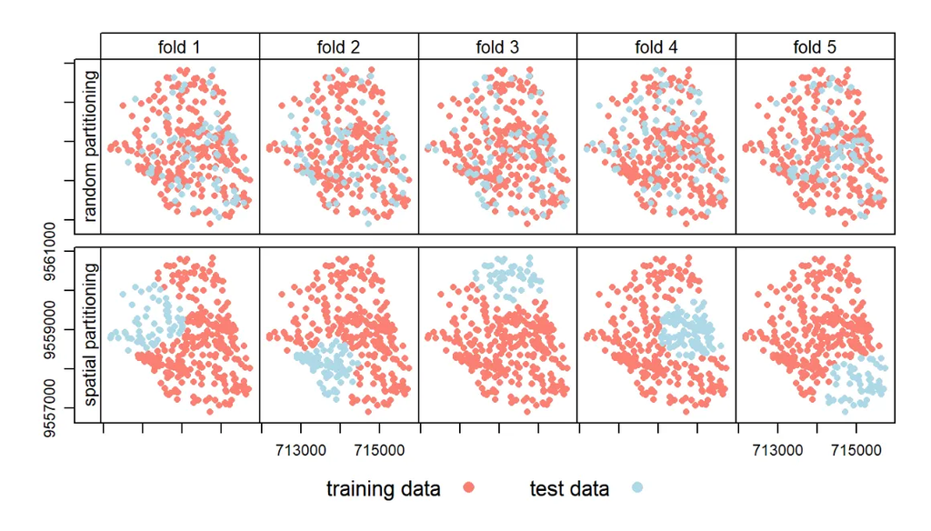

Below, I perform spatial CV to evaluate model performance. I use leave-one-block-out CV, with k=5 folds, where folds are determined by coordinate-based k-means clustering. I’ll also repeat this process 10 times, so that each time the splits are different. Overall, I create 50 models (5x10), and their average AUC will be my overall performance metric.

I’ll use the entire ecuador dataset to train the model this time, instead of 70%. I’ll keep my learner, `lrn_rf`.

```r
# setup task, using entire ecuador dataset
task = as_task_classif_st(ecuador,
                          target = "slides",
                          positive = "TRUE",
                          coordinate_names = c("x", "y"),
                          crs = "EPSG:32717",
                          coords_as_features = FALSE)
```

### 2.1 Resampling methods

There are several resampling methods for spatial/temporal data. Descriptions can be found [here](https://arxiv.org/abs/2110.12674). Be careful not to choose a value of k that is too close to n (number of observations), as withholding too little data will make each model too similar, increasing estimation bias.

```r
# set resampling method for the "perfomance" level
rsmp_perf = rsmp("repeated_spcv_coords", folds = 5, repeats = 10, id = "SpCV")
```

We can visualize these folds in R (how would this work for a repeated method…)

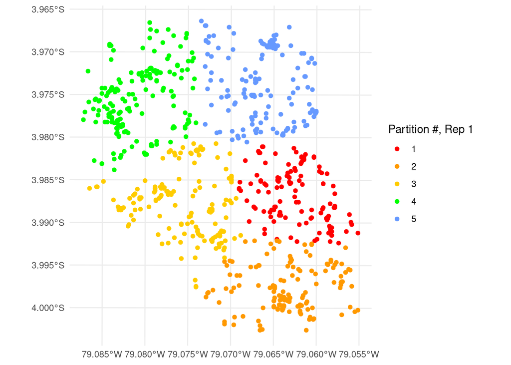

```r
# map of blocks (ie folds)
autoplot(rsmp_perf, task) +
  theme(legend.position="none") +
  theme_minimal()
```

### 2.2 Running it

At this point, I can build the model and print performance methods.

```r
# reduce verbosity
lgr::get_logger("mlr3")$set_threshold("warn")

# run spatial cross-validation
rr = resample(task = task,
              learner = lrn_rf,
              resampling = rsmp_perf)

# compute the AUC as a data.table
scores = rr$score(measure = msr("classif.auc"))

# print the mean AUC across the 5x10 models
mean(scores$classif.auc)
```

```
## [1] 0.6529948
```

Woohoo! See, CV improved predictive performance over the basic model.

## 3. Hyperparameter tuning

**Context:**

At this point, we may consider tinkering with hyperparameters and features. Let’s start with the former.

We *could* perform hyperparameter optimization (aka tuning) within each of the 50 models above. However, it’s better practice to separate the tuning process from the performance estimation process, thereby preventing overoptimistic results. This is done with nested CV, where tuning is performed in the “inner folds,” while model performance is estimated using the “outer folds.”

Below is a graphic representation of parameter tuning using 3-fold CV in the outer loop and 4-fold CV in the inner loop.

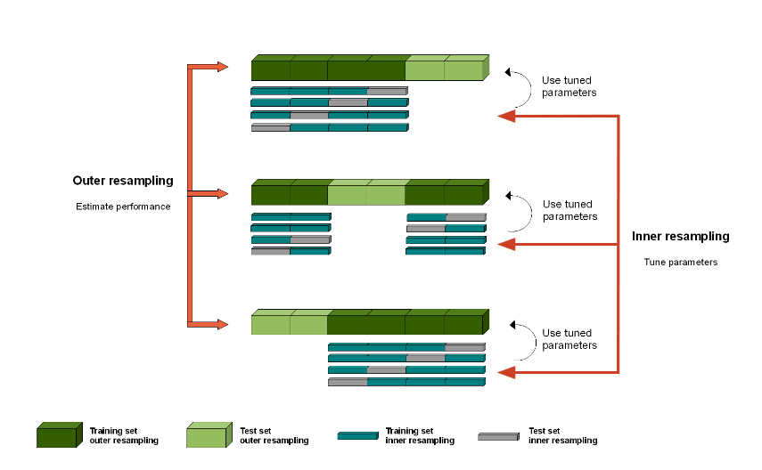

I’ll try to break it down. Within each out the 3 outer training sets, we create 4 inner folds for hyperparameter tuning. This process will determine a separate set of optimal hyperparameters for each of the 3 outer training sets. **Now we can either declare the overall optimal hyperparameters (average across …), or train a separate model for each of the training sets, using their corresponding optimized hyperparameters, and evaluate model performance…**

Schratz et al., 2019 argues that the same spatial resampling method should be use for the inner CV as the outer. In our spatial case, that means spatial nested CV! Below is a comparison of spatial vs non-spatial partitioning for the outer (performance) and inner (tuning) levels.

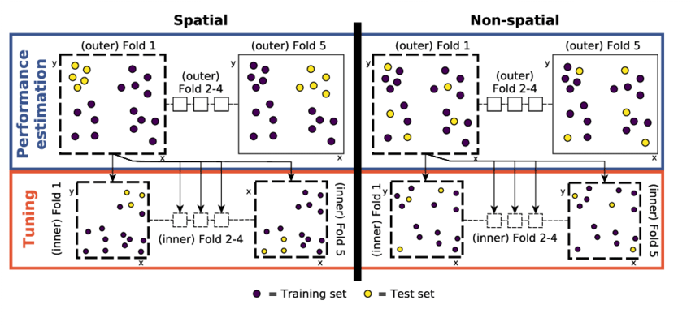

Note that the effect of tuning on model performance is more pronounced for certain algorithms than others. For example, SVM tends to benefit from tuning more than RF. Also, keep in mind that Schratz et al., 2019 found that the impact of hyperparameter tuning on predictive performance was found to be less significant than the differences between the different ML algorithms themselves.

### 3.1 Resampling at the tuning level

First, I’ll specify the resampling method for inner, or “tuning,” level folds. I’ll again use leave-one-block-out CV. So here, I split each outer fold into 3 spatially disjoint sub-folds, which are used to determine the optimal hyperparameters for the corresponding outer fold.

```r
# specify inner resampling method
rsmp_tune = rsmp("spcv_coords", folds = 3)
```

### 3.2 Tuning space

Next, I’ll define the search space for hyperparameter tuning. This uses the “paradox” package.

```r
# specify tuning space
search_space = ps(
  mtry = p_int(lower = 1, upper = ncol(task$data()) - 1),
  sample.fraction = p_dbl(lower = 0.2, upper = 0.9)
)
```

You can also use default tuning spaces. These are retrieved with `lts()` (learner tuning space). To check out pre-set spaces, run `as.data.table(mlr3tuningspaces::mlr_tuning_spaces)`. The default tuning spaces are published in Bischl et al. (2023). Other tuning spaces are part of the random bot experiments rbv1 and rbv2 published in Kuehn et al. (2018) and Binder, Pfisterer, and Bischl (2020).

```r
search_space = lts("classif.ranger.default")
```

### 3.3 Search method (tuners)

Next, I’ll specify the hyperparameter search method. I’ll go with a random search. This step requires the `mlr3tuning` package.

Common search methods:

- Grid search: a grid of hyperparameter values is defined and the model is trained and evaluated for each combination of hyperparameters in the grid.
- Random search: hyperparameters are randomly sampled from a specified distribution. Random search is usually a good choice as it outperforms grid search in high-dimensional settings (i.e. if a lot hyperparameters have to be optimized) and has no disadvantages in low-dimensional cases (Bergstra and Bengio 2012).
- Bayesian optimization: a more advanced method, in which a probabilistic model is used to model the relationship between the hyperparameters and the model’s performance. The model is updated as new evaluations are made, and the next set of hyperparameters to be evaluated is selected based on the current model. Adaptive search algorithms, like Bayesian Optimization, offer computationally efficient solutions (`mlr3mbo` package)

To check out all search methods, run `tnrs()`.

Optional parameters (for certain tuners - not mbo) include resolution and batch_size, although default settings work well in most cases:

- resolution: # of values to try per hyperparameter
- batch_size: # of configurations to apply before the terminator checks if the termination criterion has been reached. This is also the number of configs to evaluate if parallelizing, and *may need manual adjustment*. This can get tricky, so check out the mlr3book ch10 for examples.

```r
# specify tuning search method
tuner = tnr("random_search")
```

### 3.4 Performance metrics

We need a performance metric to optimize against. I’ll use AUC, a common metric for classification models. RSME is a good one for regression models.

To check out all performance metrics run `msrs()`.

```r
# measure to optimize
msr = msr("classif.auc")
```

### 3.5 Terminators

I’ll also specify the number of hyperparameters configurations to try before stopping the optimization process within an outer fold**.** Alternatively, I could choose to terminate by time, or when a performance metric (“msr”) threshold is met. Note that this terminates the process.

**Are the 50 hyperparameters the same for each inner fold?**

To check out all terminators, run `trms()`, or go [here](https://mlr-org.com/terminators.html). `run_time` and `n_evals` are the most common terminators.

```r
# try 50 hyperparameters configs per outer fold
terminator = trm("evals", n_evals=50)
```

### 3.6 Fallback learner

It’s wise to set a backup learner too, in case our chosen method fails. This is recommended over ignoring failed iterations. `classif.featureless` simply chooses the majority class, without considering features. If our task was a regression, I’d use `regr.featureless`, which chooses the average response.

```r
# specify fallback method for inner resampling
lrn_rf$fallback = lrn("classif.featureless", predict_type = "prob")
```

### 3.7 Running it

This is going to create a lot of models. For each of the 5 outer folds, we try 50 sets of hyperparameters, and each set is trained over 3 inner folds. This process is repeated 10 times. That’s 3x50 models per outer split, 5 outer splits, and 10 repeats… so 7,500 models will be created across the entire tuning process!

That’ll take a long time. I’m going to run the tuning with lower values for now: 5 outer folds, 5 sets of hyperparameters, 2 inner folds, and 2 repetitions = 100 models.

There are a few ways to create and use a tuner in mlr3:

1. The most manual method uses `ti()`, which creates a TuningInstance. Then you’d run the tuning process with `tuner$optimize(instance)`.

   I don’t know much about this method, but here’s how it would look if we were to tune our data without nested resampling. We’re fitting 10 models in total here, and the AUC scores for each configuration are averaged over the 2 folds.

```r
### ti() ###
set.seed(1)

# initialize tuning instance
instance_ti = ti(
  task = task,
  learner = lrn_rf,
  resampling = rsmp("spcv_coords", folds = 2),
  measures = msr,
  terminator = trm("evals", n_evals=5),
  store_models = FALSE,
  search_space = search_space)

# set search method
tuner_rs = tnr("random_search")

# trigger the tuning process
tuner_rs$optimize(instance_ti)

# print AUC and optimal hyperparameters
instance_ti$result
```

```
##    mtry.ratio num.trees replace sample.fraction learner_param_vals  x_domain
##         <num>     <int>  <lgcl>           <num>             <list>    <list>
## 1:  0.1433044       480    TRUE       0.6780594          <list[5]> <list[4]>
##    classif.auc
##          <num>
## 1:   0.6083756
```

2. `tune()` is a wrapper function, creating the ti and calling `$optimize` automatically.

```r
###  tune() ###
set.seed(1)

# initialize tuning instance and trigger tuning process
instance_tune = tune(
  tuner = tuner_rs,
  task = task,
  learner = lrn_rf,
  resampling = rsmp("spcv_coords", folds = 2),
  measures = msr,
  terminator = trm("evals", n_evals=5),
  store_models = FALSE)

# print result
instance_tune$result
```

```
##    learner_param_vals  x_domain classif.auc
##                <list>    <list>       <num>
## 1:          <list[1]> <list[0]>    0.636474
```

3. `auto_tuner()` wraps a learner with tuning specifications. Tuning is triggered when `$train()` is called, finding and applying optimal hyperparameters during the training process.

   Here’s where we fit 100 models.

```r
###  auto_tuner() ###
set.seed(1)

# wrap learner with tuning specs
lrn_at = auto_tuner(
  tuner = tuner_rs,
  learner = lrn_rf,
  resampling = rsmp("spcv_coords", folds = 2),
  measure = msr,
  terminator = trm("evals", n_evals=5),
  search_space = search_space)

# build model with hyperparam tuning using nested spatial CV
resample(task = task,
         learner = lrn_at,
         resampling  = rsmp("repeated_spcv_coords", folds = 5, repeats = 2, id = "SpCV"),
         store_models = FALSE,     # set to TRUE to analyze the tuning
         encapsulate = "evaluate") # continue processing if one of the models throws an error
```

Or just print the optimal hyperparameters.

```r
set.seed(1)

# why does this only run 3 configs?
# this will tune over all of the data in your task
tuning_result = lrn_at$train(task)
print(lrn_at$tuning_result)
```

[output not shown]

## 4. Feature Selection

```r
instance = fselect(
  fselector = fs("sequential"),
  task =  tsk_pen,
  learner = lrn_rpart,
  resampling = rsmp("cv", folds = 3),
  measure = msr("classif.acc")
)
```

# Prediction

```r
# predict over our data
autotuner_rf$predict(task)

# predict over a raster
pred = terra::predict(ep,
                      model = autotuner_rf,
                      fun = predict)
```

# Comparing models

Although the model optimization methods above provide performance evaluation, the results are optimistically biased because the evaluation is conducted on the same data used for tuning and selection. Information from the tuning process is leaked into the evaluation.

```r
# specify a learner - here we'll use a classification tree
lrn_rpart = lrn("classif.rpart", predict_type = "prob")

# specify resampling method = nonspatial
rsmp_nsp = rsmp("repeated_cv", folds = 3, repeats = 2, id = "NSpCV")

# specify resampling method = spatial
rsmp_sp = rsmp("repeated_spcv_coords", folds = 3, repeats = 2, id = "SpCV")

# compare performance - see that NSpCV "does better," but it's biased!
design = benchmark_grid(tsk_ecuador, lrn_rpart, c(rsmp_nsp, rsmp_sp))
bmr = benchmark(design)
bmr$aggregate(msr("classif.acc"))[, c(5, 7)]

# visualize model comparison
(autoplot(rsmp_sp, tsk_ecuador, fold_id = 1, size = 0.7) +
  ggtitle("Spatial Resampling") +
  autoplot(rsmp_nsp, tsk_ecuador, fold_id = 1, size = 0.7) +
  ggtitle("Non-spatial Resampling")) +
  plot_layout(guides = "collect") &
  theme_minimal() &
  theme(axis.text = element_text(size = 4), legend.position = "bottom")

# classification error ("ce") of each task/learner combo
bmr$aggregate()[, .(task_id, learner_id, classif.ce)]

# visualize classification accuracy
autoplot(bmr, measure = msr("classif.acc"))

# print optimal hyperparams and feature importance...
data = as.data.table(bmr)
outer_learners = map(data$learner, "learner")
xgb_tuned_model = outer_learners[[3]]
print(xgb_tuned_model)
print(xgb_tuned_model$importance())
```

# Running in parallel

multisession: separate R sessions running in the background on the same machine

```r
# get available cores
w = future::availableCores() # my computer has 20

# This is computationally intensive. Let's parallelize the inner loop, using all available cores
future::plan("multisession", workers = w)

# We're all set up for nested spcv hyperparam tuning!

progressr::with_progress(expr = {
  rr_spcv_svm = mlr3::resample(task = task,
                               learner = at_ksvm,        # svm with the nested resampling scheme
                               resampling = perf_level,  # outer resampling scheme
                               store_models = FALSE,     # set to TRUE if you wanna do a follow-up analyses on the tuning.
                               encapsulate = "evaluate") # processing continues even if one of the models throws an error
})

# stop parallelization
future:::ClusterRegistry("stop")

# I have no idea why I'm getting this error: Warning message: The fallback learner 'classif.featureless' and the base learner 'classif.ksvm.tuned' have different predict types: 'response' != 'prob'.

# compute the AUROC values
score_spcv_svm =
  rr_spcv_svm$score(measure = mlr3::msr("classif.auc")) %>%
  select(score_spcv_svm, task_id, learner_id,
                               resampling_id, classif.auc)

# print the mean AUROC
mean(score_spcv_svm$classif.auc)
```

# References

Bischl, Bernd, Martin Binder, Michel Lang, Tobias Pielok, Jakob Richter, Stefan Coors, Janek Thomas. “Hyperparameter Optimization: Foundations, Algorithms, Best Practices and Open Challenges.” *Wiley Interdisciplinary Reviews: Data Mining and Knowledge Discovery* (2023).

B. Bischl, Bernd, O. Mersmann, H. Trautmann, C. Weihs. “Resampling Methods for Meta-Model Validation with Recommendations for Evolutionary Computation.” *Evol Comput* (2012): 20 (2): 249-275.

R. Lovelace, J. Nowosad, and J. Muenchow. [Statistical Learning: Spatial CV](https://geocompr.robinlovelace.net/spatial-cv.html) (2021), Geocomputation with R.

H. Meyer et al. “Importance of spatial predictor variable selection in machine learning applications–Moving from data reproduction to spatial prediction.” *Ecological Modelling* 411 (2019): 108815.

P. Schratz et al. “Hyperparameter tuning and performance assessment of statistical and machine-learning algorithms using spatial data.” *Ecological Modelling* 406 (2019): 109-120.

P. Schratz et al. “Mlr3spatiotempcv: Spatiotemporal resampling methods for machine learning in R.” *ArXiv* 406 (2021): preprint.